# LTER_allometry

CML & CAK

2022-09-22

## Introduction

We selected the and_vertebrates database from the LTER site ( https://lter.github.io/lterdatasampler/reference/and_vertebrates.html):

The dataset includes count and size data for cutthroat trout and salamanders in clear cut or old growth sections of Mack Creek, Andrews Forest LTER.

```
## here() starts at C:/Users/cris/Desktop/OptimizandoR_Sep22/LTER_CML_CAK
```

[output not shown]

| ...1 | year | sitecode | section | reach | pass | unitnum | unittype | vert_index | pitnumber | species | length_1_mm | length_2_mm | weight_g | clip | sampledate | notes |
| --- | --- | --- | --- | --- | --- | --- | --- | --- | --- | --- | --- | --- | --- | --- | --- | --- |
| 1 | 1987 | MACKCC-L | CC | L | 1 | 1 | R | 1 | NA | Cutthroat trout | 58 | NA | 1.75 | NONE | 1987-10-07 | NA |
| 2 | 1987 | MACKCC-L | CC | L | 1 | 1 | R | 2 | NA | Cutthroat trout | 61 | NA | 1.95 | NONE | 1987-10-07 | NA |
| 3 | 1987 | MACKCC-L | CC | L | 1 | 1 | R | 3 | NA | Cutthroat trout | 89 | NA | 5.60 | NONE | 1987-10-07 | NA |
| 4 | 1987 | MACKCC-L | CC | L | 1 | 1 | R | 4 | NA | Cutthroat trout | 58 | NA | 2.15 | NONE | 1987-10-07 | NA |
| 5 | 1987 | MACKCC-L | CC | L | 1 | 1 | R | 5 | NA | Cutthroat trout | 93 | NA | 6.90 | NONE | 1987-10-07 | NA |
| 6 | 1987 | MACKCC-L | CC | L | 1 | 1 | R | 6 | NA | Cutthroat trout | 86 | NA | 5.90 | NONE | 1987-10-07 | NA |

## Plot the raw data

In this case, we are interested in modeling the length-mass relationships for cutthroat trout and salamanders in Mack Creek:

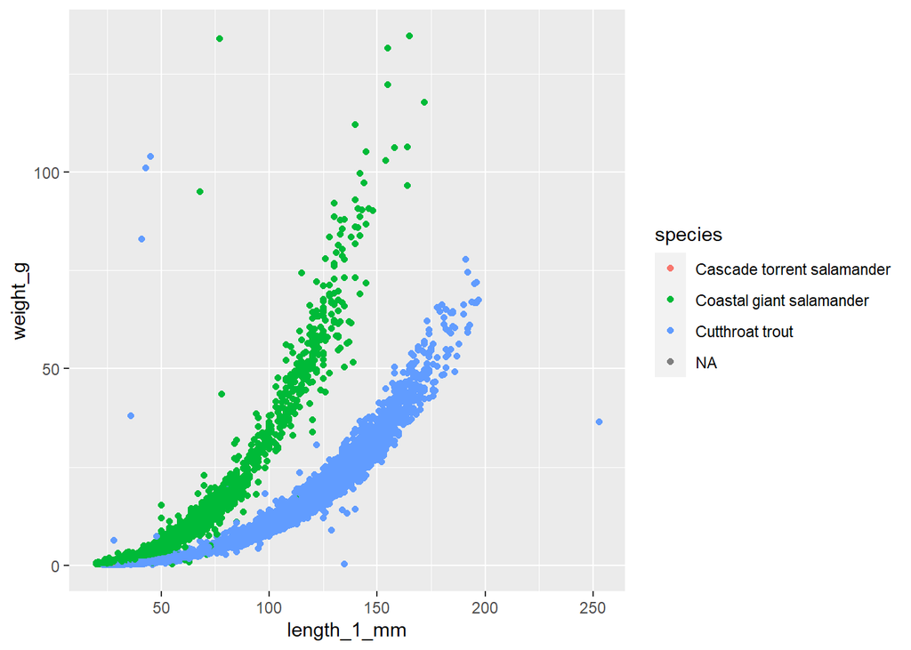

There are three species sampled but the Cascade torrent salamander is almost absent from the dataset, so we decided to ignore this species from our analysis.

First we subsampled the dataset and then plotted it:

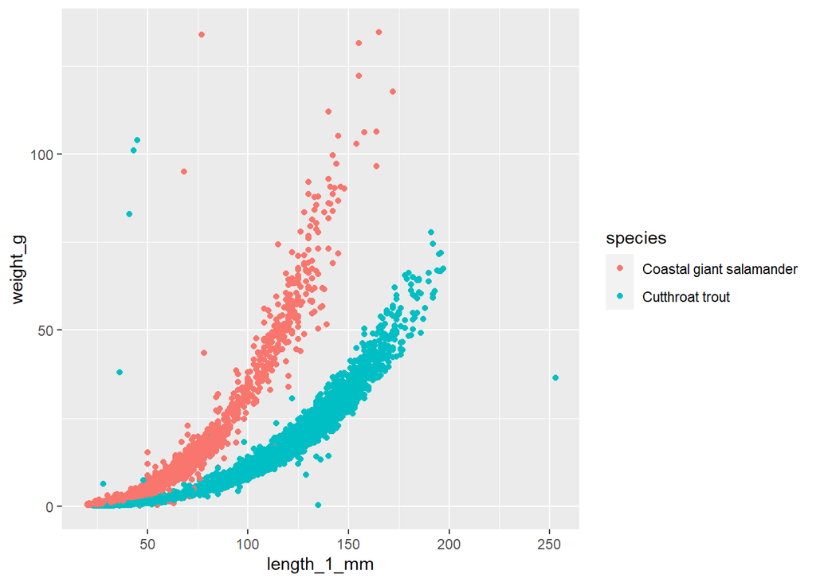

```r
data_species2 <- ourdata %>%
  subset(species != "Cascade torrent salamander")

data_species2$species <- as.factor(data_species2$species)
ggplot(data_species2, aes(x = length_1_mm,
                    y = weight_g,
                    color = species)) +
  geom_point()
```

The reason for log10 transform the biomass is because we have many small values (near zero) and wanted to enlarge the distribution “scale”

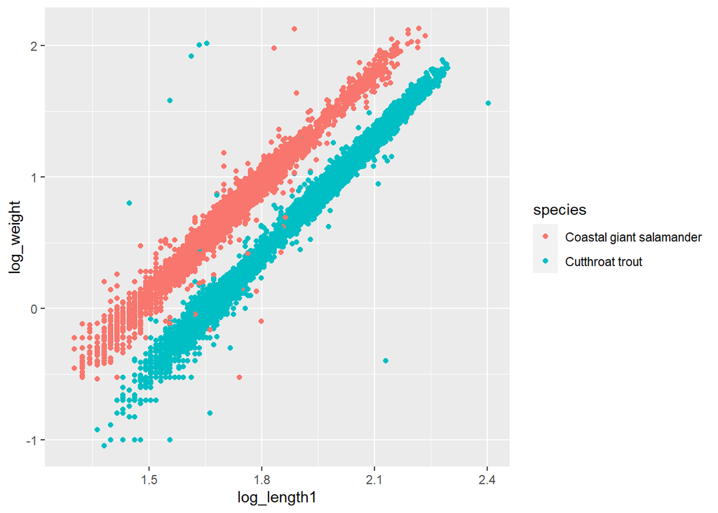

```r
data_species_log <- data_species2
data_species_log$log_length1 <- log10(data_species_log$length_1_mm)
data_species_log$log_weight <- log10(data_species_log$weight_g)

ggplot(data_species_log, aes(x = log_length1,
                             y = log_weight,
                             color = species)) +
  geom_point()
```

Result: It worked. The relationship is almost linear. We now model the allometric relationship between the length and biomass of these species and check whether the curves per species are different. We will check if the models “follow” the assumptions :

```r
lm_log_species <- lm(log_weight ~ log_length1 + species, data=data_species_log)
summary(lm_log_species)
```

```
##
## Call:
## lm(formula = log_weight ~ log_length1 + species, data = data_species_log)
##
## Residuals:
##      Min       1Q   Median       3Q      Max
## -1.77068 -0.03244  0.00066  0.03173  2.08377
##
## Coefficients:
##                         Estimate Std. Error t value Pr(>|t|)
## (Intercept)            -4.299328   0.005009  -858.3   <2e-16 ***
## log_length1             2.922709   0.002860  1021.8   <2e-16 ***
## speciesCutthroat trout -0.554276   0.001184  -468.0   <2e-16 ***
## ---
## Signif. codes:  0 '***' 0.001 '**' 0.01 '*' 0.05 '.' 0.1 ' ' 1
##
## Residual standard error: 0.07131 on 18918 degrees of freedom
##   (13270 observations deleted due to missingness)
## Multiple R-squared:  0.9823, Adjusted R-squared:  0.9823
## F-statistic: 5.263e+05 on 2 and 18918 DF,  p-value: < 2.2e-16
```

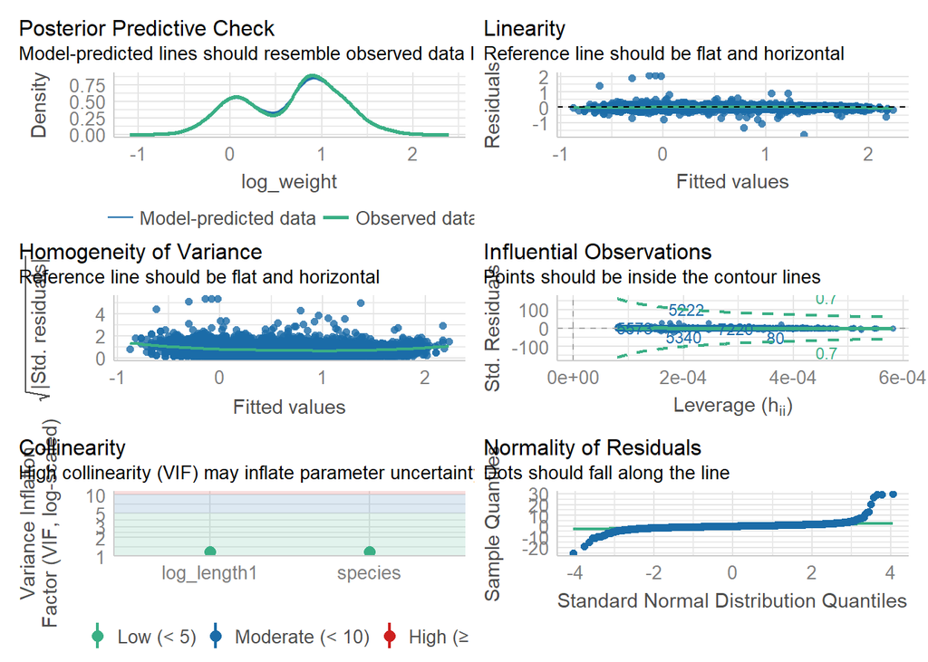

```r
check_model(lm_log_species)
```

```r
lm_log_species_i <- lm(log_weight ~ log_length1 * species, data=data_species_log)
summary(lm_log_species_i)
```

```
##
## Call:
## lm(formula = log_weight ~ log_length1 * species, data = data_species_log)
##
## Residuals:
##      Min       1Q   Median       3Q      Max
## -1.77696 -0.03225  0.00075  0.03096  2.08983
##
## Coefficients:
##                                     Estimate Std. Error t value Pr(>|t|)
## (Intercept)                        -4.157994   0.010196 -407.81   <2e-16 ***
## log_length1                         2.840679   0.005895  481.87   <2e-16 ***
## speciesCutthroat trout             -0.742230   0.011893  -62.41   <2e-16 ***
## log_length1:speciesCutthroat trout  0.106861   0.006728   15.88   <2e-16 ***
## ---
## Signif. codes:  0 '***' 0.001 '**' 0.01 '*' 0.05 '.' 0.1 ' ' 1
##
## Residual standard error: 0.07084 on 18917 degrees of freedom
##   (13270 observations deleted due to missingness)
## Multiple R-squared:  0.9826, Adjusted R-squared:  0.9826
## F-statistic: 3.556e+05 on 3 and 18917 DF,  p-value: < 2.2e-16
```

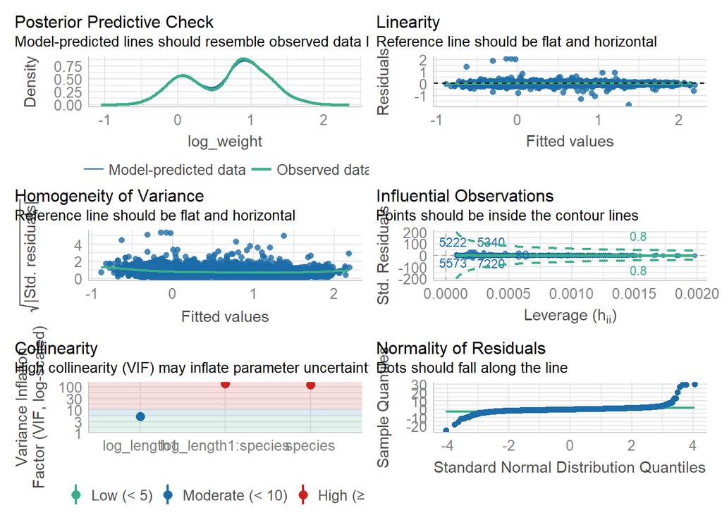

```r
check_model(lm_log_species_i)
```